# 3 Feature Encoding

In this chapter we load the data, experiment with different model architectures and finally train the autoencoder model.

### Imports:

```python
import keras
from keras.models import load_model
from keras.datasets import cifar10
from keras.layers import Input, Flatten, Reshape, UpSampling2D, Dense, Conv1D, Conv2D, MaxPooling2D, GlobalMaxPooling2D, UpSampling2D, BatchNormalization, Activation
from keras import layers
from keras.models import Model
from keras.callbacks import EarlyStopping, ModelCheckpoint
from keras.optimizers import Adam
from keras.callbacks import TensorBoard
from matplotlib import pyplot as plt
import tensorflow as tf
import datetime
import numpy as np
import pandas as pd
import seaborn as sns
import pickle
```

## 3.1 Dataset Preparation

In this section we import the CIFAR-10 dataset which consists of 60000 32x32 colour images in 10 classes. For each class 6000 samples are available. The dataset was originally described in the report "Learning Multiple Layers of Features" by Tiny Images, Alex Krizhevsky in 2009 (Chapter 3).

### Load Data

```python
# Load Data
(x_train, y_train), (x_test, y_test) = cifar10.load_data()
```

The then classes are encoded as an integer value:

- 0 = airplane
- 1 = automobile
- 2 = bird
- 3 = cat
- 4 = deer
- 5 = dog
- 6 = frog
- 7 = horse
- 8 = ship
- 9 = truck

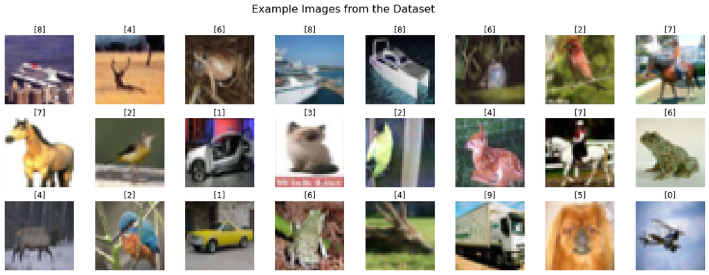

```python
# display random images from the dataset

cols = 8
rows = 3
fig = plt.figure(figsize=(2.5 * cols - 1, 2.5 * rows - 1))
for i in range(cols):
    for j in range(rows):
        random_index = np.random.randint(0, len(y_train))
        ax = fig.add_subplot(rows, cols, i * rows + j + 1)
        ax.grid('off')
        ax.axis('off')
        ax.imshow(x_train[random_index, :])
        ax.set_title(str(y_train[random_index]))

fig.suptitle("Example Images from the Dataset", fontsize=16)
plt.show()
```

### Normalize the Data

Each pixel is represented as three integer values between 0 and 255 (Red, Green, Blue).

```python
print("Single Pixel:", x_train[1][1][1])
```

```
Single Pixel: [145 153 154]
```

Dividing each RGB value by the max value (255) to scale them between 0 and 1. Doing this no information is lost.

```python
x_train = x_train.astype('float32')
x_test = x_test.astype('float32')
x_train /= 255
x_test /= 255
```

```python
print("Single normalized Pixel:", x_train[1][1][1])
```

```
Single normalized Pixel: [0.5686275 0.6       0.6039216]
```

Color distributions of the first ten images after normalization:

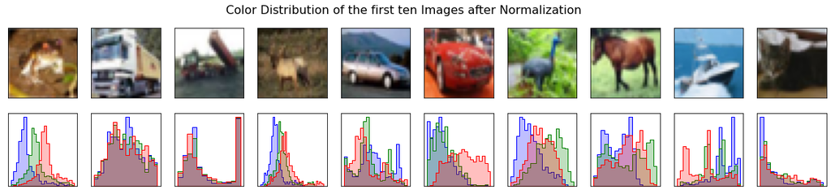

```python
n = 10
plt.figure(figsize=(20, 4))

for i in range(n):

    img = x_train[i]

    # display original
    ax = plt.subplot(2, n, i+1)
    plt.imshow(img.reshape(32, 32, 3))
    ax.get_xaxis().set_visible(False)
    ax.get_yaxis().set_visible(False)

    # display color distribution
    ax = plt.subplot(2, n, i +1 + n)
    ax.get_xaxis().set_visible(False)
    ax.get_yaxis().set_visible(False)

    #Red
    red_values = [pixel[0] for row in img for pixel in row ]
    red = pd.DataFrame({'color': ["red"] * 32 * 32, 'value': red_values } )

    # Green
    green_values = [pixel[1] for row in img for pixel in row ]
    green = pd.DataFrame({'color': ["green"] * 32 * 32, 'value': green_values } )

    # Blue
    blue_values = [pixel[2] for row in img for pixel in row ]
    blue = pd.DataFrame({'color': ["blue"] * 32 * 32, 'value': blue_values } )

    sns.histplot(pd.concat([red, green, blue]), x="value", hue="color", element="step",
                 palette = ["red", "green", "blue"], ax = ax, legend= False)

plt.suptitle("Color Distribution of the first ten Images after Normalization", fontsize=16)
plt.show()
```

50000 images are used to train the model while 10000 are hold back for evaluation purposes. The y values indicating the classes are not used during the unsupervised training but are helpful analysing the results. Shapes of the train and test data sets:

```python
print('Train Samples Shape:\t\t', x_train.shape)
print('Train Samples Classes Shape:\t', y_train.shape)
print('Test  Samples Shape:\t\t', x_test.shape)
print('Test  Samples Classes Shape:\t', y_test.shape)
```

```
Train Samples Shape:		 (50000, 32, 32, 3)
Train Samples Classes Shape:	 (50000, 1)
Test  Samples Shape:		 (10000, 32, 32, 3)
Test  Samples Classes Shape:	 (10000, 1)
```

### Save Data

```python
pickle.dump(x_train, open( "./data/x_train.p", "wb" ))
pickle.dump(y_train, open( "./data/y_train.p", "wb" ))
pickle.dump(x_test,  open( "./data/x_test.p",  "wb" ))
pickle.dump(y_test,  open( "./data/y_test.p",  "wb" ))
```